# 통계밥법론 Chap7 실습코드

202140191 엄태훈

2021-05-01(SAT)

# Chap7 Multiple Comparisons

우리는 앞서 분산분석(ANOVA)을 진행해보고 집단간 평균 차이에 유무에 대한 결과를 얻을 수 있었다.  
만약, 분산분석의 결과로 ’적어도 한 집단간 차이가 존재한다’라는 결과를 도출하면, 우리는 어느 집단에서 차이가 존재하고, 어느 정도의 차이가 존재하는지에 대한 궁금증이 생길것 이다.

이러한 경우 진행하는 분석이 바로 다중 비교(사후 분석이라고도 한다.)이다.  
다중비교의 경우 실험 조건의 평균들을 대상으로 여러번 비교를 수행하는 것이다.

즉, 집단이 A,B,C 3개라면 3번의 비교를 진행하는 것이다.  
*A-B, A-C, B-C*

다중비교에서 가장 많이 사용되는 분석은 *Bonferroni*, *Dunnett*, *Tukey*, *scheffe*가 있다.

*Bonferroni*는 T 검정을 사용하여 그룹 평균 간 쌍대 비교를 수행하는 것이다.  
- 집단의 수가 동일하지 않아도 사용이 가능하다.  
- 유의수준을 1/n으로 낮추어 다중 비교에서 생기는 오류를 보정한다.  
Ex) 유의수준 = 0.05, 평균 쌍 비교 개수 = 5,  
사후검정에서의 유의수준 alpha는 다음과 같이 계산된다.

$$Bonferroni\; \alpha = {0.05\div5 } = 0.01$$

*Dunnett*은 하나의 집단을 기준으로 다른 집단들과 차이에 대하여 분석하는 방법이다.  
- 유의성이 작은 집단에 대한 차이를 검정할 정도로 검정력이 뛰어나다.  
- 하나의 집단을 기준으로 하기 때문에, 모든 집단 조합에대한 검정을 하지 않는다.

*Tukey*는 비교되는 모든 집단의 표본 수가 동일한 경우 평균차를 비교하는 방법이다.  
- 비교 대상 표본수가 반드시 동일해야 한다.  
- 표본수가 동일할 경우 가장 많이 쓰이는 방법이다.  
- 표본수가 적을수록 정확도가 낮아진다.

*scheffe*는 단순하게 집단간 비교하는 것 외에도 모든 경우의 수를 비교하며, 집단간 표본의 수가 달라도 사용이 가능한 방법이다.  
- 집단을 소극적으로 분리시킨다.  
- 하지만, 통계적으로 유의한 차이를 도출하기 쉽지않다.

## 7.1 Multiple Comparison Procedures

### 7.1.3 The Dunnett Procedure for Comparing One Mean

with All Others

```r
library(HH)
```

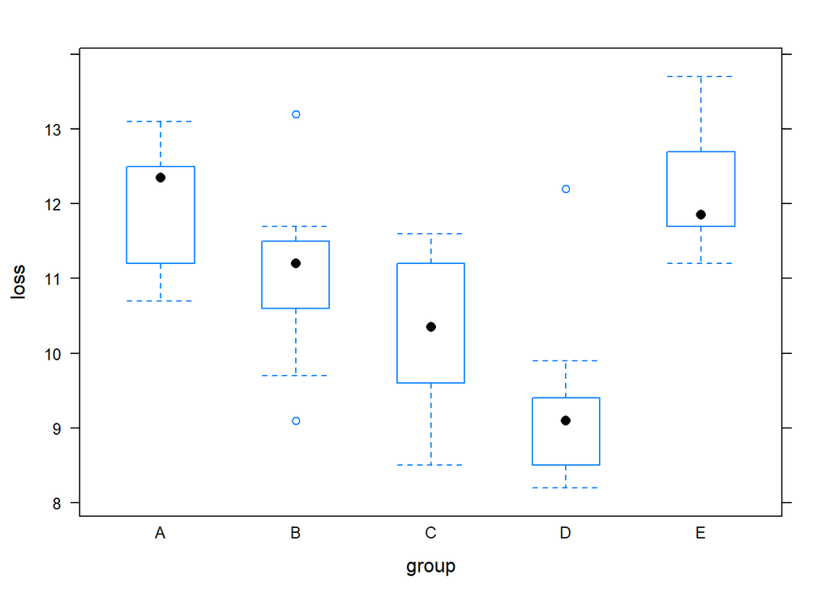

```r
data(weightloss)
bwplot(loss~group,data=weightloss,xlab="group")
```

R에서의 `aov`함수를 이용하여 분산분석을 진행할 수 있다.  
`aov(자료변수~집단변수,data=데이터명)`  
- *자료변수*: 자료들의 정보를 갖고있는 변수를 넣는다.  
- *집단변수*: 집단의 정보를 갖고있는 변수를 넣는다.  
- *data*: 변수들을 갖고있는 데이터를 넣는다.

```r
library(HH)
data(weightloss)

weightloss.aov <- aov(loss ~ group,data=weightloss)

summary(weightloss.aov)
```

```
##             Df Sum Sq Mean Sq F value   Pr(>F)
## group        4  59.88  14.970   15.07 6.88e-08 ***
## Residuals   45  44.70   0.993
## ---
## Signif. codes:  0 '***' 0.001 '**' 0.01 '*' 0.05 '.' 0.1 ' ' 1
```

분산분석 결과, P-value는 유의수준 0.05보다 작으므로 *적어도 한 집단간에서 평균 차이가 존재한다.*는 결론을 도출할 수 있다.

집단간 평균차이가 존재하므로 다중비교(사후분석)을 통해 어느 집단에서 차이가 발생했는지를 분석한다.

R에서는 `glht`함수를 통해 일반화된 선형 가설 검정과 다중비교를 진행할 수 있다.

다중비교를 진행하는 것이기 때문에 분산분석을 진행한 결과를 넣어줘야한다.

이번예제에서는 우측검정을 기반으로한 dunnett 방법을 이용하기 위해 mcp를 통해 linfct의 옵션을 세부적으로 설정해 주었다.

```r
mcp(group=contrMat(
    table(weightloss$group),base=4),
    alternative = "greater")
```

```
## $group
##
##   Multiple Comparisons of Means: Dunnett Contrasts
##
##       A B C  D E
## A - D 1 0 0 -1 0
## B - D 0 1 0 -1 0
## C - D 0 0 1 -1 0
## E - D 0 0 0 -1 1
##
## $alternative
## [1] "greater"
##
## attr(,"interaction_average")
## [1] FALSE
## attr(,"covariate_average")
## [1] FALSE
## attr(,"class")
## [1] "mcp"
```

앞선 boxplot에서 D그룹이 가장 작은 평균값을 가졌기 때문에, *Dunnet*방법을 이용하기 위해 `base=4`를 통해 D그룹을 기준변수로 지정해주었다.

첫 번째 줄의 (1,0,0,-1,0)은 기준변수인 D로 A를 비교하겠다.  
두 번째 줄의 (0,1,0,-1,0)은 기준변수인 D로 B와 비교하겠다.  
라는 의미이다.

가설검정은 `greater`를 통해 우측검정으로 지정해주었다.

`glht(model,linfct=mcp(그룹변수=다중비교방법))`  
- *model*: 분산분석의 결과가 저장된 객체를넣는다.  
- *linfct*: 다중비교 방법을 지정해준다.

#### 7.1.3.1 Computing Note—Specifying the Alternative Hypothesis

```r
weightloss.dunnett <-
  glht(weightloss.aov,linfct=mcp(group=contrMat(
    table(weightloss$group),base=4)),
    alternative = "greater")
confint(weightloss.dunnett)
```

```
##
##   Simultaneous Confidence Intervals
##
## Multiple Comparisons of Means: User-defined Contrasts
##
##
## Fit: aov(formula = loss ~ group, data = weightloss)
##
## Quantile = -2.2217
## 95% family-wise confidence level
##
##
## Linear Hypotheses:
##            Estimate lwr      upr
## A - D <= 0 2.780000 1.789693      Inf
## B - D <= 0 1.750000 0.759693      Inf
## C - D <= 0 1.000000 0.009693      Inf
## E - D <= 0 2.900000 1.909693      Inf
```

우측검정을 기준으로 하였기 때문에, 기각역의 상한 band는 inf임을 알 수 있다.  
추정값이 모두 기각역안에 들어가므로 귀무가설을 기각함을 알 수 있다.  
따라서, D그룹변수와 나머지 그룹변수 간에 모두 유의한 차이가 존재함을 알 수 있다.

`summary`함수를 이용해 유의확률을 통해서도 사후검정 결과를 살펴볼 수 있다.

```r
summary(weightloss.dunnett)
```

```
##
##   Simultaneous Tests for General Linear Hypotheses
##
## Multiple Comparisons of Means: User-defined Contrasts
##
##
## Fit: aov(formula = loss ~ group, data = weightloss)
##
## Linear Hypotheses:
##            Estimate Std. Error t value Pr(>t)
## A - D <= 0   2.7800     0.4457   6.237 <0.001 ***
## B - D <= 0   1.7500     0.4457   3.926 <0.001 ***
## C - D <= 0   1.0000     0.4457   2.243 0.0479 *
## E - D <= 0   2.9000     0.4457   6.506 <0.001 ***
## ---
## Signif. codes:  0 '***' 0.001 '**' 0.01 '*' 0.05 '.' 0.1 ' ' 1
## (Adjusted p values reported -- single-step method)
```

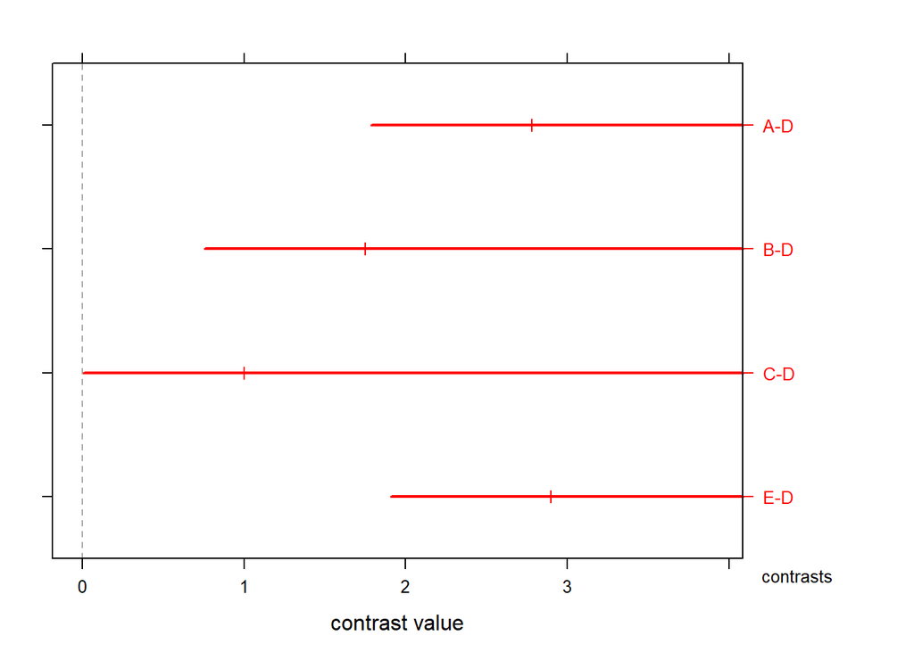

```r
mmcplot(weightloss.dunnett,lwd=2)
```

사후검정의 결과를 그림으로 나타낸 결과, 모두 빨간색으로 지정되어 D그룹과 나머지 그룹간 평균차이가 존재하는 것을 시각적으로 살펴볼 수 있다.

`DescTools`패키지의 `DunnettTest`함수를 통해서도 *DunnettTest*를 진행할 수 있다.  
앞서 진행한 분석의 경우, 분산분석을 진행한 후 분산분석의 결과를 객체에 저장해야 됐었지만, `DunnettTest`함수의 경우에는 Formula형식으로 입력을 해주면 자동으로 사후분석을 진행해준다.

`DunnettTest(자료변수~그룹변수,데이터,control)`  
- *자료변수*: 자료의 정보를 갖고있는 변수를 넣어준다.  
- *그룹변수*: 그룹의 정보를 갖고있는 변수를 넣어준다.  
- *데이터*: 변수들의 정보를 갖고있는 데이터를 넣어준다.  
- *control*: 기준변수를 지정해준다.

```r
library(DescTools)
DunnettTest(loss~group,data=weightloss,control="D")
```

```
##
##   Dunnett's test for comparing several treatments with a control :
##     95% family-wise confidence level
##
## $D
##     diff     lwr.ci   upr.ci    pval
## A-D 2.78  1.6515054 3.908495 3.3e-07 ***
## B-D 1.75  0.6215054 2.878495  0.0011 **
## C-D 1.00 -0.1284946 2.128495  0.0954 .
## E-D 2.90  1.7715054 4.028495 8.1e-08 ***
##
## ---
## Signif. codes:  0 '***' 0.001 '**' 0.01 '*' 0.05 '.' 0.1 ' ' 1
```

분산분석의 객체 저장을 진행하지 않고도 바로 사후분석의 결과를 얻는것을 확인할 수 있다.

`HH`패키지의 `mmc`함수를 통해서도 다중비교 분석을 진행할 수 있다.  
`mmc`함수의 경우의 입력방법은 앞서 살펴본 `glht`함수와 상당히 유사하다.

```r
weightloss.mmc <-
  mmc(weightloss.aov,
      linfct=mcp(group=
                   contrMat(table(weightloss$group),
                            base=4)),
      alternative = "greater")
weightloss.mmc
```

```
## Dunnett contrasts
## Fit: aov(formula = loss ~ group, data = weightloss)
## Estimated Quantile = -2.221724
## 95% family-wise confidence level
## $mca
##     estimate stderr       lower upper height
## E-D     2.90   -Inf 1.909687963   Inf 10.720
## A-D     2.78   -Inf 1.789687963   Inf 10.660
## B-D     1.75   -Inf 0.759687963   Inf 10.145
## C-D     1.00   -Inf 0.009687963   Inf  9.770
## $none
##   estimate stderr     lower upper height
## E    12.17   -Inf 11.469744   Inf  12.17
## A    12.05   -Inf 11.349744   Inf  12.05
## B    11.02   -Inf 10.319744   Inf  11.02
## C    10.27   -Inf  9.569744   Inf  10.27
## D     9.27   -Inf  8.569744   Inf   9.27
```

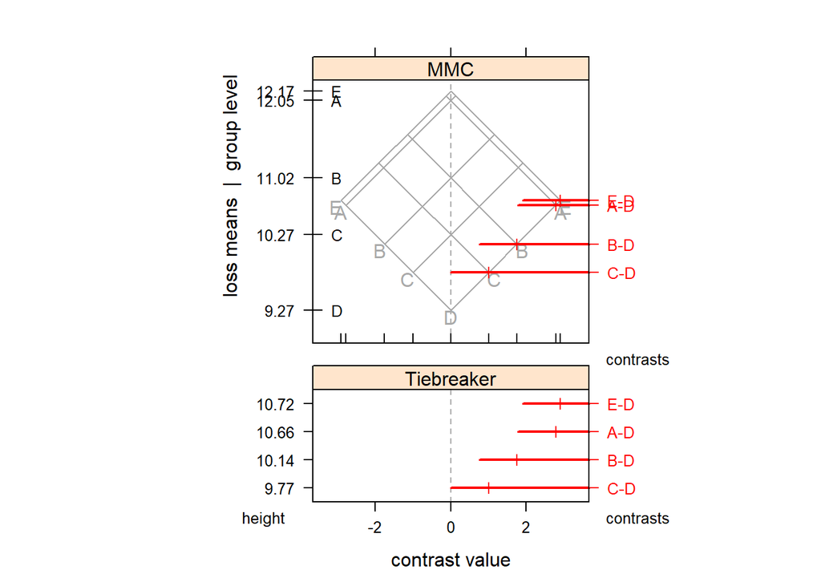

```r
mmcplot(weightloss.mmc,style="both",lwd=2)
```

### 7.1.4 Simultaneously Comparing All Possible Contrasts Scheff´e and Extended Tukey

#### 7.1.4.1 The Scheff´e Procedure

*scheffe*방법에는 tukrey 데이터를 이용하여 진행한다.

```r
data(turkey)
turkey.aov <- aov(wt.gain ~ diet, data=turkey)

#scheffe method에 calpha을 구한다.

scheffe.quantile <- sqrt(4*qf(.95,4,25))
```

사후분석을 진행하기에 앞서, 비교할 대상에 대한 contrast matrix를 만들어준다.  
첫 번째의 경우 control과 나머지 그룹을 비교하기 위해 (1,-.25,-.25,-.25,-.25)로 설정한 것을 확인할 수 있다.  
나머지 contrast matrix들도 비교하고자 하는 집단에 따라 구성됐다.

```r
turkey.lmat <-
  cbind(control.vs.treatment = c(1,-.25,-.25,-.25,-.25),
        A.vs.B = c(0,.5,.5,-.5,-.5),
        amount = c(0,.5,-.5,.5,-.5),
        A.vs.B.by.amount = c(0,.5,-.5,-.5,.5))
row.names(turkey.lmat) <- row.names(contrasts(turkey$diet))
```

앞서 설정한 *contrast matrix*를 비교군으로 설정하고, calpha 또한 앞에서 quantile을 이용해 구했던 객체를 지정해주었다.

```r
turkey.mmc <- mmc(turkey.aov,calpha=scheffe.quantile,focus = "diet",focus.lmat=turkey.lmat,
                  estimate.sign=0,
                  order.contrasts = FALSE)
```

A. vs.B.by.amount는 신뢰구간이 0을 포함하므로 집단간 차이가 유의하지 않은 것을 알 수 있다.

나머지 그룹의 경우 신뢰구간이 0을 포함하지 않으므로 집단간 차이가 발생하며, 신뢰구간과 추정치를 통해 어느정도의 차이가 나는지 확인할 수 있다.

*mmcplot*을 통해서도 A.vs.B.by.amount를 제외한 나머지 그룹이 빨간색으로 지정된 것을 통해 유의한 차이가 있음을 확인할 수 있다.  
*mmcplot*에서 `type='lmat`를 지정하면 우리가 설정한 contrast matrix에 대한 차이만을 그림으로 나타낼 수 있다.

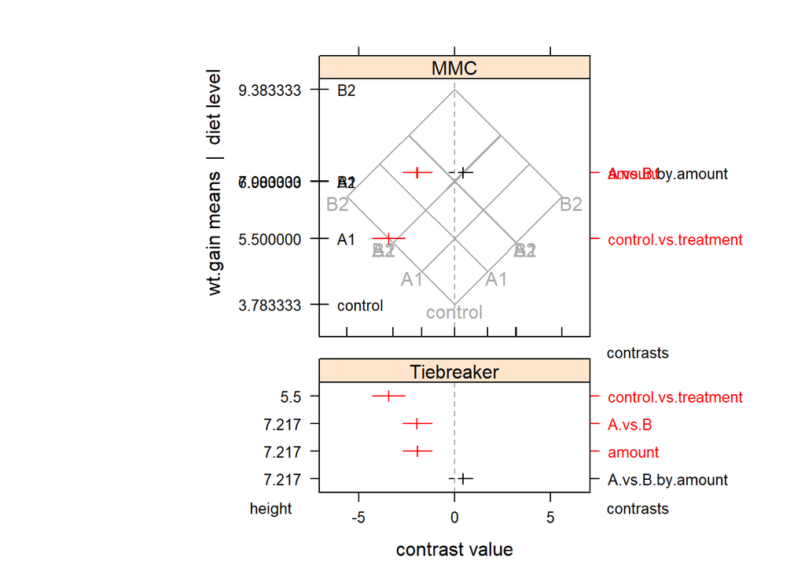

```r
mmcplot(turkey.mmc,type="lmat",style="both")
```

`style = confint`을 지정하면 신뢰구간에 대한 그림만을 보여준다.

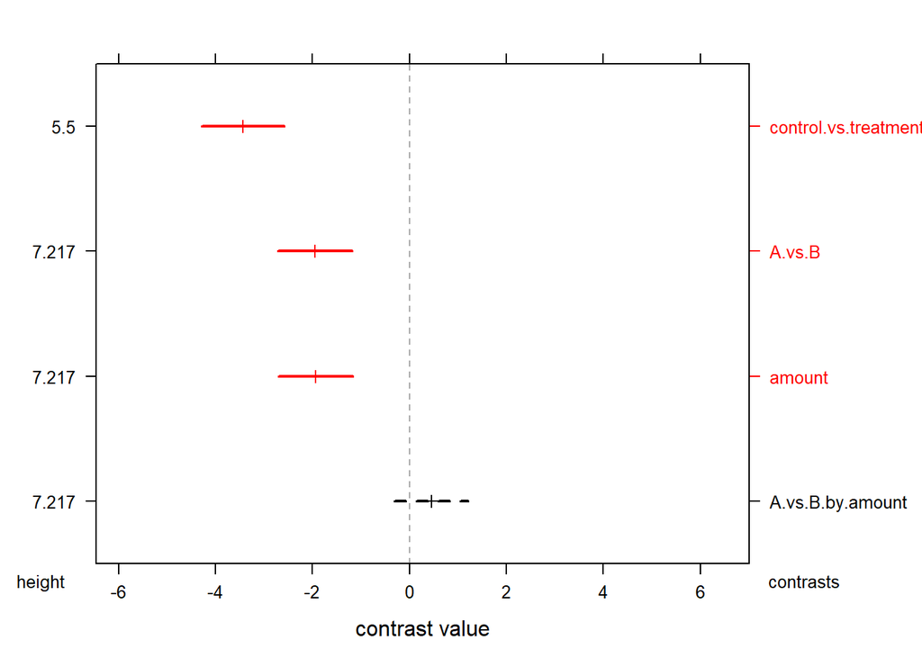

```r
mmcplot(turkey.mmc,type="lmat",style="confint",lwd=2)
```

lmat(contrast matrix)에 대한 설정을 하지 않고 turkey.mmc를 객체로 입력하면 전체의 그룹간 차이를 살펴볼 수 있다.

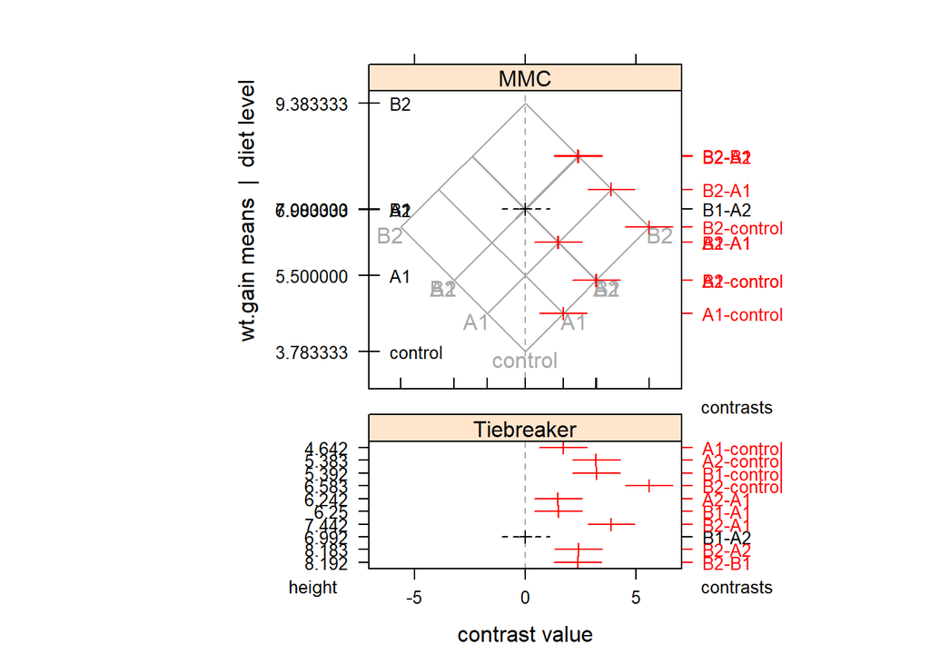

```r
mmcplot(turkey.mmc,style="both")
```

## 7.2 The Mean-Mean Multiple Comparisons Display (MMC Plot)

### 7.2.1 Difficulties with Standard Displays

```r
data(catalystm)
catalystm1.aov <- aov(concent~catalyst,data=catalystm)
catalystm.glht <- glht(catalystm1.aov,
                       linfct=mcp(catalyst="Tukey"))
confint(catalystm.glht)
```

```
##
##   Simultaneous Confidence Intervals
##
## Multiple Comparisons of Means: Tukey Contrasts
##
##
## Fit: aov(formula = concent ~ catalyst, data = catalystm)
##
## Quantile = 2.9655
## 95% family-wise confidence level
##
##
## Linear Hypotheses:
##            Estimate  lwr       upr
## B - A == 0 -1.125000 -4.501041  2.251041
## C - A == 0 -3.666667 -7.342035  0.008702
## D - A == 0 -5.775000 -9.151041 -2.398959
## C - B == 0 -2.541667 -6.385459  1.302125
## D - B == 0 -4.650000 -8.208660 -1.091340
## D - C == 0 -2.108333 -5.952125  1.735459
```

catalystm의 데이터를 이용하여 사후분석을 진행하였다.  
사후분석의 경우 *Tukey*방법을 이용하였다.  
*Tukey*의 경우 비교하는 집단 간 표본의 수가 같아야 사용할 수 있지만, 프로그램에서는 표본의 수가 달라도 사용할 수 있도록 만들어져있다.

A-D, B-D를 제외하고 모두 신뢰구간에 0이 포함된다. 따라서, A-D, B-D의 집단만이 유의한 차이를 가지고 있다고 할 수 있다.

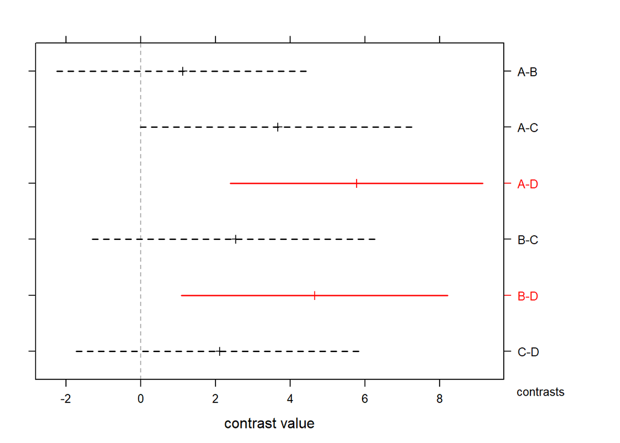

```r
mmcplot(catalystm.glht,style="confint",lwd=1.5)
```

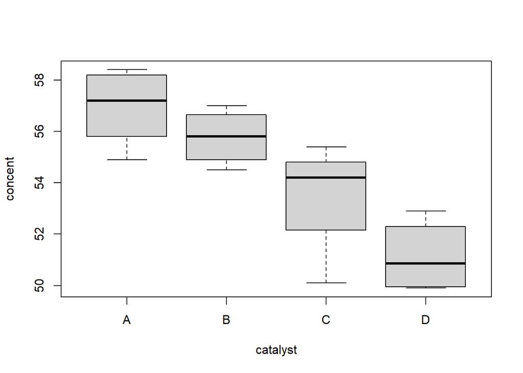

```r
boxplot(concent~catalyst,data=catalystm)
```

앞서 진행한 *Tukey*분석의 경우 표본의 수가 동일하지 않을때, 사후검정을 진행하였다.  
그렇다면 *Tukey*분석에서 집단 간 표본의 크기를 같게하고, 표본의 크기가 클 때와 작을 때를 비교하면 어떤 결과가 나오는지 알아보자.

`aovSufficient`함수는그룹에 대한 충분통계량을 이용하여 분산분석을 진행하는 방법이다.

```r
group <- factor(LETTERS[1:4])
n <- c(5,100,100,5)
ybar <- c(2,2.1,2.8,3)
inconsistent.aov <- aovSufficient(ybar ~ group, weight=n, sd=.8)
anova(inconsistent.aov)
```

```
## Analysis of Variance Table
##
## Response: ybar
##            Df  Sum Sq Mean Sq F value    Pr(>F)
## group       3  27.024  9.0079  14.075 2.213e-08 ***
## Residuals 206 131.840  0.6400
## ---
## Signif. codes:  0 '***' 0.001 '**' 0.01 '*' 0.05 '.' 0.1 ' ' 1
```

분산분석 결과, 유의확률은 유의수준 0.05보다 작으므로 적어도 한 그룹 이상에서 유의한 차이를 보인다고 할 수 있다.

```r
# Tukey의 확률값을 이용하여 임계값을 구한다.
crit.point <- qtukey(.95,4,206)/sqrt(2)

inconsistent.glht <-
  glht(inconsistent.aov, linfct=mcp(group="Tukey"),
       vcov=vcovSufficient,df=inconsistent.aov$residuals)
confint(inconsistent.glht,calpha=crit.point)
```

```
##
##   Simultaneous Confidence Intervals
##
## Multiple Comparisons of Means: Tukey Contrasts
##
##
## Fit: aov(formula = formula, data = data, weights = weights, x = TRUE)
##
## Quantile = 2.5901
## 95% confidence level
##
##
## Linear Hypotheses:
##            Estimate lwr      upr
## B - A == 0  0.10000 -0.84956  1.04956
## C - A == 0  0.80000 -0.14956  1.74956
## D - A == 0  1.00000 -0.31051  2.31051
## C - B == 0  0.70000  0.40696  0.99304
## D - B == 0  0.90000 -0.04956  1.84956
## D - C == 0  0.20000 -0.74956  1.14956
```

*Tukey*를 이용한 사후분석 결과 신뢰구간에서 0을 포함하지 않는 그룹은 C-B 하나 뿐인 것을 확인할 수 있다.  
따라서, C-B는 유의한 차이가 존재하는 것을 확인할 수 있다.

여기서, C-B의 경우 표본의 수가 100으로 상당히 큰 표본의 수를 가지며, 비교대상끼리 같은 표본의 수를 가지는 것을 확인할 수 있다.  
A,D의 경우에는 비교 대상간 표본의 수가 같지만 표본의 수가 5개로 매우 작은 것을 확인할 수 있다.

이를 통해, 우리는 *Tukey* 사후분석의 경우, 집단간 표본의 수가 같고 클수록 더 정확한 검정을 진행하는 것을 알 수 있다.

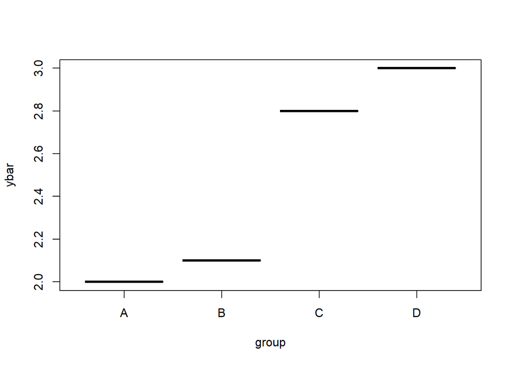

```r
boxplot(ybar~group)
```

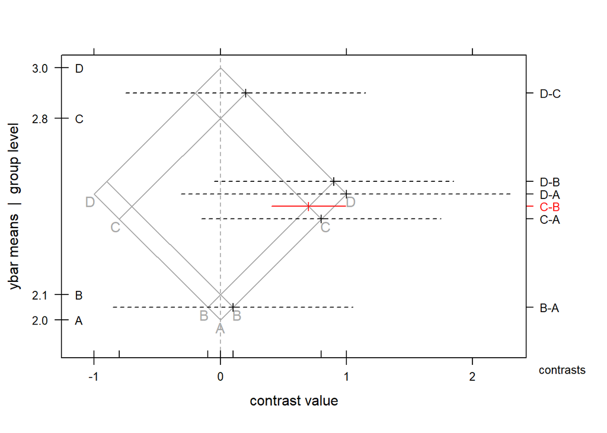

```r
mmcplot(mmc(inconsistent.aov,calpha=crit.point))
```

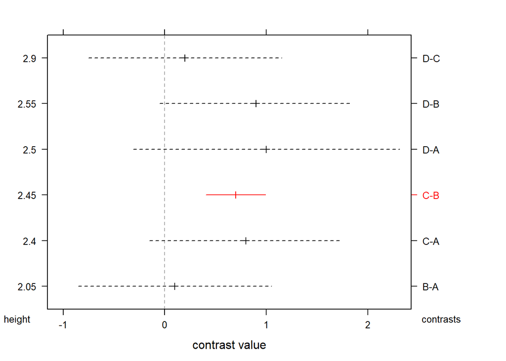

```r
mmcplot(mmc(inconsistent.aov,calpha=crit.point),style="confint")
```

C-B의 그룹간 차이만이 유의하기 때문에 빨간색으로 표시되어 나타나는 것을 확인할 수 있다.

```r
inconsistent.mmc2 <- mmc(inconsistent.aov,calpha=crit.point)
```

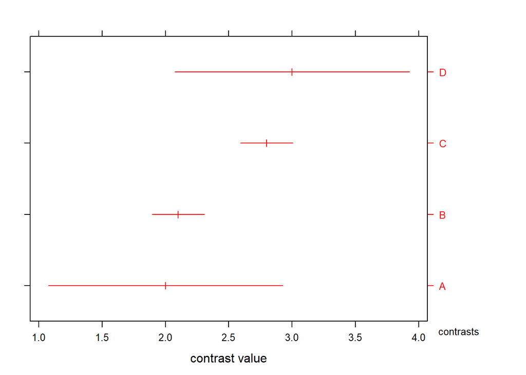

```r
mmcplot(inconsistent.mmc2$none)
```

#### 7.2.2.1 Construction of the Mean-Mean Scatterplot

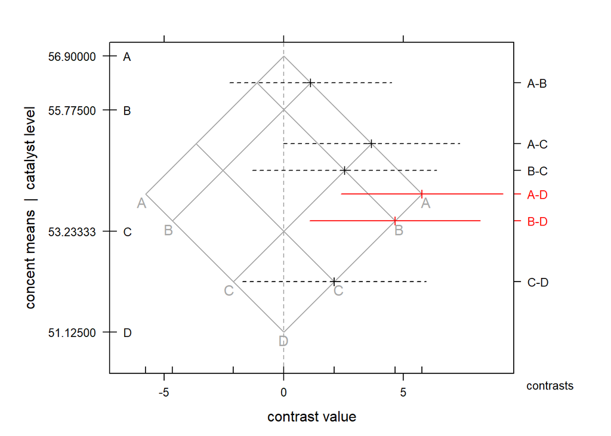

```r
catalystmi.aov <- aov(concent~catalyst,data=catalystm)
catalystm.mmc <-
  mmc(catalystmi.aov,linfct=mcp(catalyst="Tukey"))
mmcplot(catalystm.mmc)
```

`interaction2wt` 함수는 주효과와 교호작용을 시각화 시켜줌으로써 한 눈에 살펴볼 수 있는 함수이다.

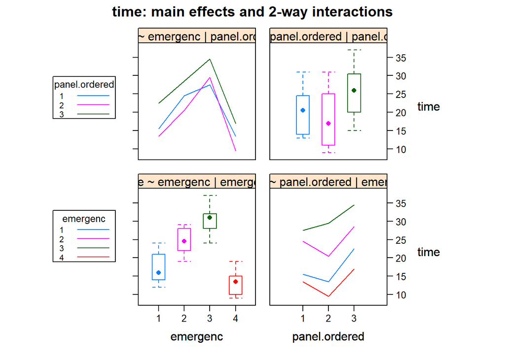

```r
data(display)
interaction2wt(time ~ emergenc * panel.ordered, data=display)
```

## 7.2.4 Display of an Orthogonal Basis Set of Contrasts

```r
## aov contrast matrix for catalyst factor. The columns are
## constructed by contr.treatment with the default base = 1
contrasts(catalystm$catalyst)
```

```
##   B C D
## A 0 0 0
## B 1 0 0
## C 0 1 0
## D 0 0 1
```

Base를 설정해주지 않을경우, 자동으로 첫 번째 그룹변수가 base가 된다.  
catalyst의 경우 A가 첫 번째 그룹변수이기 때문에 기준 그룹변수로 지정되는 것을 확인할 수 있다.

```r
## Linear function used internaily by glht for pairwise contrasts
## The rows of linfct are the difference of the columns
## of the contrast matrix

catalystmi.aov <- aov(concent~catalyst,data=catalystm)
catalystm.mmc <-
  mmc(catalystmi.aov,linfct=mcp(catalyst="Tukey"))
catalystm.mmc$mca$glht$linfct
```

```
##     (Intercept) catalystB catalystC catalystD
## A-B           0        -1         0         0
## A-C           0         0        -1         0
## B-C           0         1        -1         0
## A-D           0         0         0        -1
## B-D           0         1         0        -1
## C-D           0         0         1        -1
```

mmc의 분석결과에서도 base에 대한 기준이 지정되지 않아 catalystA라는 변수가 아닌 (Intercept)로 지정이 되는 것을 확인할 수 있다.

```r
## Contrasts in lmat format, each column sums to zero.
## The last three rows are the transpose of the last three columns
## of the linfct matrix.
## The first row is prepended to make the column sum be zero.
catalyst.pairwise <- lmatPairwise(catalystm.mmc)
catalyst.pairwise
```

```
##   A-B A-C B-C A-D B-D C-D
## A   1   1   0   1   0   0
## B  -1   0   1   0   1   0
## C   0  -1  -1   0   0   1
## D   0   0   0  -1  -1  -1
```

`lmatPairwise`를 이용하여 contrast matrix를 살펴본 결과, 비교 하는 대상간(열을 기준으로)은 항상 합이 0이 되는 것을 확인할 수 있다.  
예를 들어, A와 B를 비교할때, A를 기준으로 하므로 A=1, B는 비교대상이므로 B= -1 이고 두 개의 합은 0이다.

```r
## An orthogonal set of ($4-1$) contrasts for the catalyst factor.
## user-spcified contrasts
catalystm.lmat <- cbind("AB-D" = c(1,1,0,-2),
                        "A-B" = c(1,-1,0,0),
                        "ABD-C" = c(1,1,-3,1))

dimnames(catalystm.lmat)[[1]] <- levels(catalystm$catalyst)
catalystm.lmat
```

```
##   AB-D A-B ABD-C
## A    1   1     1
## B    1  -1     1
## C    0   0    -3
## D   -2   0     1
```

정확히 두 집단만 비교하는 것이 아니라 원하는 다중 집단을 비교할수도 있다.  
첫 번째 열의 *AB-D*의 경우, A와B를 기준으로 비교를 하기 때문에 A,B를 각각 1,1, 비교대상 D를 -2로 설정하였다. (합은 항상 0이어야 한다.)  
세 번째 열의 *ABD-C*의 경우, A,B,D를 기준으로 비교를 하기 때문에 A,B,D에 각각 (1,1,1), 비교대상 C를 -3으로 설정하였다.

```r
crossprod(catalystm.lmat)
```

```
##       AB-D A-B ABD-C
## AB-D     6   0     0
## A-B      0   2     0
## ABD-C    0   0    12
```

```r
catalyst.pairwise
```

```
##   A-B A-C B-C A-D B-D C-D
## A   1   1   0   1   0   0
## B  -1   0   1   0   1   0
## C   0  -1  -1   0   0   1
## D   0   0   0  -1  -1  -1
```

```r
resid(lm(catalystm.lmat ~ catalyst.pairwise))
```

```
##   AB-D A-B ABD-C
## A    0   0     0
## B    0   0     0
## C    0   0     0
## D    0   0     0
```

```r
catalystm.mmc <-
  mmc(catalystm1.aov,linfct=mcp(catalyst="Tukey"),
      focus.lmat=catalystm.lmat)
catalystm.mmc
```

```
## Tukey contrasts
## Fit: aov(formula = concent ~ catalyst, data = catalystm)
## Estimated Quantile = 2.965437
## 95% family-wise confidence level
## $mca
##     estimate   stderr        lower    upper   height
## A-B 1.125000 1.138447 -2.250994483 4.500994 56.33750
## A-C 3.666667 1.239385 -0.008650604 7.341984 55.06667
## B-C 2.541667 1.296179 -1.302072139 6.385405 54.50417
## A-D 5.775000 1.138447  2.399005517 9.150994 54.01250
## B-D 4.650000 1.200029  1.091389355 8.208611 53.45000
## C-D 2.108333 1.296179 -1.735405473 5.952072 52.17917
## $none
##   estimate    stderr    lower    upper   height
## A 56.90000 0.7589649 54.64934 59.15066 56.90000
## B 55.77500 0.8485486 53.25868 58.29132 55.77500
## C 53.23333 0.9798195 50.32774 56.13893 53.23333
## D 51.12500 0.8485486 48.60868 53.64132 51.12500
## $lmat
##       estimate   stderr     lower    upper   height
## A-B   1.125000 1.138447 -2.250994 4.500994 56.33750
## ABD-C 1.366667 1.088144 -1.860156 4.593489 53.91667
## AB-D  5.212500 1.021788  2.182452 8.242548 53.73125
```

다중비교 결과, 우리가 설정한 3가지의 집단에 대해서도 결과가 알맞게 출력된 것을 확인할 수 있다.  
AB-D는 신뢰구간에서 0을 포함하지 않으므로 집단간 유의한 차이가 존재하는 것을 알 수 있다.

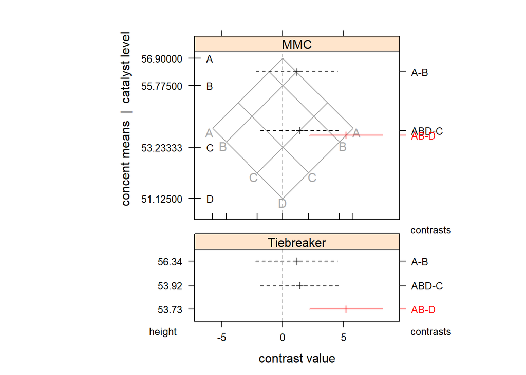

```r
mmcplot(catalystm.mmc,type="lmat",style="both")
```

*mmcplot*함수에서 *type = “lmat”*옵션을 지정하게 되면 우리가 설정한 *contrast matrix*에 대한 `mmcplot`을 그릴 수 있다.  
AB-D의 집단간 차이가 유의하여 빨간색으로 지정된 것을 알 수 있다.